# How should I price auto insurance in the United States?

## Introduction

**Business Context.** The ability to price an insurance quote properly has a significant impact on insurers' management decisions and financial statements. You are the chief data scientist at a new startup insurance company focusing on providing affordable insurance to millennials. You are tasked to assess the current state of insurance companies to see what factors large insurance providers charge premiums for. Fortunately for you, your company has compiled a dataset by surveying what people currently pay for insurance from large companies. Your findings will be used as the basis of developing your company's millenial car insurance offering.

**Business Problem.** Your task is to build a **minimal** model to predict the cost of insurance from the data set using various characteristics of a policyholder.

**Analytical Context.** The data resides in a CSV file which has been pre-cleaned for you and can directly be read in. Throughout the case, you will be iterating on your initial model many times based on common pitfalls that arise which we discussed in previous cases. You will be using the Python `statsmodels` package to create and analyze these linear models.

```python
### Load relevant packages

import pandas                  as pd
import numpy                   as np
import matplotlib.pyplot       as plt
import seaborn                 as sns
import statsmodels.api         as sm
import statsmodels.formula.api as smf
import os

# This statement allow to display plot without asking to
%matplotlib inline

# always make it pretty
plt.style.use('ggplot')
```

## Diving into the data

```python
df = pd.read_csv('Allstate-cost-cleaned.csv',
    dtype = { # indicate categorical variables
        'A': 'category',
        'B': 'category',
        'C': 'category',
        'D': 'category',
        'E': 'category',
        'F': 'category',
        'G': 'category',
        'car_value': 'category',
        'state': 'category'
    }
)
```

The following are the columns in the dataset:

1. **state**: State where shopping point occurred
2. **group_size**: How many people will be covered under the policy (1, 2, 3 or 4)
3. **homeowner**: Whether the customer owns a home (0=no, 1=yes)
4. **car_age**: Age of the customer's car (How old the car is)
5. **car_value**: Value of the car when it was new
6. **risk_factor**: An ordinal assessment of how risky the customer is (0,1, 2, 3, 4)
7. **age_oldest**: Age of the oldest person in customer's group
8. **age_youngest**: Age of the youngest person in customer's group
9. **married_couple**: Does the customer group contain a married couple (0=no, 1=yes)
10. **C_previous**: What the customer formerly had or currently has for product option C (0=nothing, 1, 2, 3,4)
11. **duration_previous**: How long (in years) the customer was covered by their previous issuer
12. **A,B,C,D,E,F,G**: The coverage options:
13. **A**: Collision (levels: 0, 1, 2);
14. **B**: Towing (levels: 0, 1);
15. **C**: Bodily Injury (BI, levels: 1, 2, 3, 4);
16. **D**: Property Damage (PD, levels 1, 2, 3);
17. **E**: Rental Reimbursement (RR, levels: 0, 1);
18. **F**: Comprehensive (Comp, levels: 0, 1, 2, 3);
19. **G**: Medical/Personal Injury Protection (Med/PIP, levels: 1, 2, 3, 4)
20. **cost**: cost of the quoted coverage options

```python
df.head(10)
```

|  | Unnamed: 0 | state | group_size | homeowner | car_age | car_value | risk_factor | age_oldest | age_youngest | married_couple | C_previous | duration_previous | A | B | C | D | E | F | G | cost |
| --- | --- | --- | --- | --- | --- | --- | --- | --- | --- | --- | --- | --- | --- | --- | --- | --- | --- | --- | --- | --- |
| 0 | 0 | OK | 1 | 0 | 9 | f | 0.0 | 24 | 24 | 0 | 3.0 | 9.0 | 0 | 0 | 1 | 1 | 0 | 0 | 4 | 543 |
| 1 | 1 | OK | 1 | 0 | 9 | f | 0.0 | 24 | 24 | 0 | 3.0 | 9.0 | 2 | 1 | 1 | 3 | 1 | 3 | 2 | 611 |
| 2 | 2 | PA | 1 | 1 | 7 | f | 0.0 | 74 | 74 | 0 | 2.0 | 15.0 | 2 | 0 | 2 | 3 | 1 | 2 | 2 | 691 |
| 3 | 3 | PA | 1 | 1 | 7 | f | 0.0 | 74 | 74 | 0 | 2.0 | 15.0 | 2 | 0 | 2 | 3 | 1 | 2 | 2 | 695 |
| 4 | 4 | AR | 1 | 0 | 4 | d | 4.0 | 26 | 26 | 0 | 3.0 | 1.0 | 1 | 0 | 1 | 1 | 0 | 2 | 2 | 628 |
| 5 | 5 | AR | 1 | 0 | 4 | d | 4.0 | 26 | 26 | 0 | 3.0 | 1.0 | 1 | 0 | 2 | 1 | 0 | 2 | 2 | 625 |
| 6 | 6 | AR | 1 | 0 | 4 | d | 4.0 | 26 | 26 | 0 | 3.0 | 1.0 | 1 | 0 | 2 | 1 | 0 | 2 | 2 | 628 |
| 7 | 7 | OK | 1 | 0 | 13 | f | 3.0 | 22 | 22 | 0 | 0.0 | 0.0 | 0 | 0 | 1 | 1 | 0 | 0 | 2 | 596 |
| 8 | 8 | OK | 1 | 0 | 13 | f | 3.0 | 22 | 22 | 0 | 0.0 | 0.0 | 2 | 0 | 1 | 1 | 0 | 3 | 2 | 711 |
| 9 | 9 | OK | 1 | 0 | 13 | f | 3.0 | 22 | 22 | 0 | 0.0 | 0.0 | 2 | 0 | 1 | 1 | 0 | 3 | 2 | 722 |

### Exercise 1 (30 min):

Write code to visualize the relationship between cost and the following variables. Choose your plots judiciously based on what you know about each variable. Different variable types (categorical vs. numerical) should have different types of plots (e.g. scatter, boxplot, violin plot, etc.) Group your plots together using the `plt.subplot()` function.

1. `car_age`
2. `age_oldest`
3. `age_youngest`
4. `duration_previous`
5. `C_previous`
6. `homeowner`
7. `group_size`
8. `car_age`
9. Categories A-G (7 different plots)

**Answer.** One possible solution is shown below:

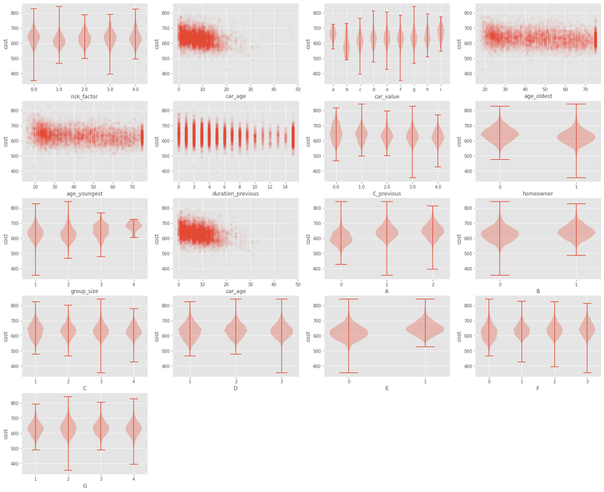

```python
plt.figure(figsize=(24,20))
vars_to_look = ['risk_factor', 'car_age', 'car_value', 'age_oldest', 'age_youngest',
              'duration_previous', 'C_previous', 'homeowner', 'group_size',
              'car_age', 'A', 'B', 'C', 'D', 'E', 'F', 'G'
]

for i, feature in enumerate(vars_to_look):
    plt.subplot(5, 4, i+1)
    col_values = df[feature]
    unique = sorted(set(col_values.dropna().values))
    if len(unique) < 10:
        # categorical: let's make a violin plot
        plt.violinplot([df.cost.values[col_values == level] for level in unique],
                       positions=range(len(unique)))
        plt.xticks(range(len(unique)), labels=unique)
    else:
        plt.scatter(col_values.values, df.cost.values, alpha=0.01, edgecolor=None)
    plt.xlabel(feature)
    plt.ylabel('cost')
```

### Exercise 2 (5 min):

Convert all categorical data to be in the one-hot encoding format.

**Answer.** We do the following:

```python
df_onehot = pd.get_dummies(df, columns=['state', 'car_value', 'A', 'B', 'C', 'D', 'E', 'F', 'G'])
```

```python
df_onehot.head(10)
```

|  | Unnamed: 0 | group_size | homeowner | car_age | risk_factor | age_oldest | age_youngest | married_couple | C_previous | duration_previous | ... | E_0 | E_1 | F_0 | F_1 | F_2 | F_3 | G_1 | G_2 | G_3 | G_4 |
| --- | --- | --- | --- | --- | --- | --- | --- | --- | --- | --- | --- | --- | --- | --- | --- | --- | --- | --- | --- | --- | --- |
| 0 | 0 | 1 | 0 | 9 | 0.0 | 24 | 24 | 0 | 3.0 | 9.0 | ... | 1 | 0 | 1 | 0 | 0 | 0 | 0 | 0 | 0 | 1 |
| 1 | 1 | 1 | 0 | 9 | 0.0 | 24 | 24 | 0 | 3.0 | 9.0 | ... | 0 | 1 | 0 | 0 | 0 | 1 | 0 | 1 | 0 | 0 |
| 2 | 2 | 1 | 1 | 7 | 0.0 | 74 | 74 | 0 | 2.0 | 15.0 | ... | 0 | 1 | 0 | 0 | 1 | 0 | 0 | 1 | 0 | 0 |
| 3 | 3 | 1 | 1 | 7 | 0.0 | 74 | 74 | 0 | 2.0 | 15.0 | ... | 0 | 1 | 0 | 0 | 1 | 0 | 0 | 1 | 0 | 0 |
| 4 | 4 | 1 | 0 | 4 | 4.0 | 26 | 26 | 0 | 3.0 | 1.0 | ... | 1 | 0 | 0 | 0 | 1 | 0 | 0 | 1 | 0 | 0 |
| 5 | 5 | 1 | 0 | 4 | 4.0 | 26 | 26 | 0 | 3.0 | 1.0 | ... | 1 | 0 | 0 | 0 | 1 | 0 | 0 | 1 | 0 | 0 |
| 6 | 6 | 1 | 0 | 4 | 4.0 | 26 | 26 | 0 | 3.0 | 1.0 | ... | 1 | 0 | 0 | 0 | 1 | 0 | 0 | 1 | 0 | 0 |
| 7 | 7 | 1 | 0 | 13 | 3.0 | 22 | 22 | 0 | 0.0 | 0.0 | ... | 1 | 0 | 1 | 0 | 0 | 0 | 0 | 1 | 0 | 0 |
| 8 | 8 | 1 | 0 | 13 | 3.0 | 22 | 22 | 0 | 0.0 | 0.0 | ... | 1 | 0 | 0 | 0 | 0 | 1 | 0 | 1 | 0 | 0 |
| 9 | 9 | 1 | 0 | 13 | 3.0 | 22 | 22 | 0 | 0.0 | 0.0 | ... | 1 | 0 | 0 | 0 | 0 | 1 | 0 | 1 | 0 | 0 |

10 rows × 78 columns

## Fitting a multiple linear regression

### Exercise 3 (10 min):

Split your data into training and testing sets (an 80-20 split is a good starting point).

**Note:** Keep random seed as 1337 in the code cell

**Answer.** One possible solution is given below:

```python
np.random.seed(1337) # a seed makes the analysis reproducible
n_data = len(df_onehot)
idx_train = np.random.choice(range(n_data), int(0.8*n_data), replace=False)
idx_test  = np.asarray(list(set(range(n_data)) - set(idx_train)))
train     = df.loc[idx_train]
test      = df.loc[idx_test]
```

### Exercise 4 (30 min):

#### 4.1

Fit a multiple linear regression model to the training data regressing cost against all the other variables. Call this `model_all`. What is the AIC value?

**Answer.** One possible solution is given below:

```python
reg_formula = 'cost ~ ' + ' + '.join(col for col in df.columns if col != 'cost')
print(reg_formula)
```

```
cost ~ Unnamed: 0 + state + group_size + homeowner + car_age + car_value + risk_factor + age_oldest + age_youngest + married_couple + C_previous + duration_previous + A + B + C + D + E + F + G
```

```python
model_all = smf.ols(formula = reg_formula, data = train).fit()
print(model_all.summary())
```

```
                            OLS Regression Results
==============================================================================
Dep. Variable:                   cost   R-squared:                       0.438
Model:                            OLS   Adj. R-squared:                  0.435
Method:                 Least Squares   F-statistic:                     143.0
Date:                Mon, 16 Mar 2020   Prob (F-statistic):               0.00
Time:                        14:18:24   Log-Likelihood:                -61546.
No. Observations:               12344   AIC:                         1.232e+05
Df Residuals:                   12276   BIC:                         1.237e+05
Df Model:                          67
Covariance Type:            nonrobust
=====================================================================================
                        coef    std err          t      P>|t|      [0.025      0.975]
-------------------------------------------------------------------------------------
Intercept           683.8289      8.594     79.566      0.000     666.982     700.675
state[T.AR]           0.4072      3.106      0.131      0.896      -5.682       6.496
state[T.CO]         -10.9356      2.572     -4.252      0.000     -15.977      -5.894
state[T.CT]          28.5326      2.868      9.948      0.000      22.911      34.155
state[T.DC]          35.6920      4.593      7.772      0.000      26.690      44.694
state[T.DE]          33.3884      4.455      7.495      0.000      24.656      42.120
state[T.FL]          11.2874      2.162      5.222      0.000       7.050      15.525
state[T.GA]           6.6917      2.381      2.811      0.005       2.025      11.358
state[T.IA]         -50.9502      3.529    -14.439      0.000     -57.867     -44.034
state[T.ID]         -21.3817      4.126     -5.183      0.000     -29.469     -13.295
state[T.IN]         -11.6240      2.573     -4.518      0.000     -16.667      -6.581
state[T.KS]          -9.2766      4.385     -2.116      0.034     -17.871      -0.682
state[T.KY]          19.9873      2.925      6.833      0.000      14.254      25.721
state[T.MD]          21.4571      2.467      8.697      0.000      16.621      26.293
state[T.ME]         -36.2676      3.947     -9.189      0.000     -44.004     -28.531
state[T.MO]         -22.9082      2.975     -7.701      0.000     -28.739     -17.077
state[T.MS]          -0.9339      3.280     -0.285      0.776      -7.364       5.496
state[T.MT]         -13.4074      6.163     -2.175      0.030     -25.488      -1.327
state[T.ND]           3.1635      6.064      0.522      0.602      -8.724      15.051
state[T.NE]         -14.4920      5.632     -2.573      0.010     -25.531      -3.453
state[T.NH]         -21.4775      3.776     -5.688      0.000     -28.879     -14.076
state[T.NM]          -1.7314      3.792     -0.457      0.648      -9.164       5.701
state[T.NV]          21.1240      2.804      7.535      0.000      15.629      26.619
state[T.NY]          38.0610      2.406     15.821      0.000      33.346      42.777
state[T.OH]          -8.9122      2.309     -3.859      0.000     -13.439      -4.385
state[T.OK]         -12.2284      2.738     -4.467      0.000     -17.595      -6.862
```

[output cut: 38 more lines]

```
age_youngest         -1.0064      0.063    -16.078      0.000      -1.129      -0.884
married_couple       -9.6351      1.396     -6.900      0.000     -12.372      -6.898
C_previous           -6.2903      0.360    -17.488      0.000      -6.995      -5.585
duration_previous    -1.5291      0.073    -20.935      0.000      -1.672      -1.386
==============================================================================
Omnibus:                      540.280   Durbin-Watson:                   1.991
Prob(Omnibus):                  0.000   Jarque-Bera (JB):             1270.951
Skew:                           0.263   Prob(JB):                    1.04e-276
Kurtosis:                       4.481   Cond. No.                     5.18e+03
==============================================================================

Warnings:
[1] Standard Errors assume that the covariance matrix of the errors is correctly specified.
[2] The condition number is large, 5.18e+03. This might indicate that there are
strong multicollinearity or other numerical problems.
```

```python
print(model_all.aic)
```

```
123227.15166098613
```

#### 4.2

According to `model_all`, which states are most and least expensive?

#### 4.3

Interpret the coefficients of `group_size`, `homeowner`, `car_age`, `risk_factor`, `age_oldest`, `age_youngest` `married_couple` , `duration_previous`. Do the signs and values of these coefficients make sense to you in the context of this business problem?

**Answer.** Insurance premiums should rise with `group_size` as there is more opportunity for accidents with more drivers. Being a home owner reduces your insurance cost by about $14 on average, assuming everything else is held the same. `car_age` has a negative coefficient; this makes sense since older cars should pay less for insurance as they are worth less. Being a married couple also reduces the insurance rate. This makes sense since married couples with children tend to be more risk averse (safer drivers) or can be explained from the fact that family vehicles tend to be safer.

`duration_previous` has a negative coefficient. This makes sense as it says if a customer was insured by a previous company for a long time, it signals that the customer is not a risky driver. If the customer goes from one insurance company to other in a short amount of time, then it should be worrisome because they could be risky drivers that are constantly being punted off by various insurance companies. Finally, the coefficients of `age_oldest` and `age_youngest` are nearly zero; this makes sense since the probability and magnitude of car damage is unlikely to be monotonically related to the ages of the children.

In the context of providing a new insurance product to millennials, many of whom don't have children and are not home owners, you may want to investigate why being a home owner decreases premiums. This may be caused by the fact of companies offering discounts on car insurance in the hopes that they buy home insurance from the same place. You may also be able to undercut large providers by offering products specifically to families with no children. Finally, your company will need to address the `duration_previous` variable as this will be generally small for millennials and there may be other proxy variables that your company could use to replace it. For example, perhaps good grades in school are good indicators for future driving record.

### Exercise 5 (15 min):

Which variables from `model_all` are statistically significant? (For categorical variables, consider them to be significant if at least one of their categories are statistically significant). Refit the model using only these variables; call this `model_sig`. How does this model compare to the previous model?

**Answer.** Because we are throwing so many variables at the model, let's apply the Bonferroni correction to tighten the threshold on which to consider a variable as significant. There are a total of 73 degrees of freedom, so let's set the threshold at 0.05/73:

```python
model_all.pvalues[model_all.pvalues < 0.05/73]
```

```
Intercept            0.000000e+00
state[T.CO]          2.137535e-05
state[T.CT]          3.153268e-23
state[T.DC]          8.363619e-15
state[T.DE]          7.080387e-14
state[T.FL]          1.801734e-07
state[T.IA]          7.079358e-47
state[T.ID]          2.222626e-07
state[T.IN]          6.287826e-06
state[T.KY]          8.701327e-12
state[T.MD]          3.853557e-18
state[T.ME]          4.590141e-20
state[T.MO]          1.454234e-14
state[T.NH]          1.316009e-08
state[T.NV]          5.232374e-14
state[T.NY]          7.882166e-56
state[T.OH]          1.143611e-04
state[T.OK]          8.016043e-06
state[T.OR]          7.583678e-05
state[T.PA]          1.089400e-05
state[T.RI]          1.835259e-09
state[T.TN]          4.293990e-06
state[T.UT]          2.580922e-09
state[T.WI]          3.779751e-28
state[T.WV]          3.453295e-12
car_value[T.b]       7.736988e-11
car_value[T.c]       7.276661e-10
car_value[T.d]       4.942258e-09
car_value[T.e]       7.446082e-09
car_value[T.f]       6.542655e-09
car_value[T.g]       1.559973e-07
car_value[T.h]       2.100974e-05
A[T.1]               2.033748e-76
A[T.2]               2.052068e-71
E[T.1]               4.096149e-20
F[T.1]               5.508475e-24
F[T.2]               1.648699e-21
F[T.3]               1.686740e-06
G[T.2]               1.374134e-19
G[T.4]               6.035748e-04
homeowner            4.108244e-89
car_age              7.868098e-25
age_oldest           1.120075e-21
age_youngest         1.396670e-57
married_couple       5.471684e-12
C_previous           1.162535e-67
duration_previous    1.199104e-95
dtype: float64
```

```python
form = 'cost ~ state + car_value + A + E + F + G + homeowner + car_age + age_oldest + age_youngest + married_couple + C_previous + duration_previous'
model_sig = smf.ols(formula = form, data = train).fit()
print(model_sig.summary())
```

```
                            OLS Regression Results
==============================================================================
Dep. Variable:                   cost   R-squared:                       0.438
Model:                            OLS   Adj. R-squared:                  0.435
Method:                 Least Squares   F-statistic:                     162.1
Date:                Mon, 16 Mar 2020   Prob (F-statistic):               0.00
Time:                        14:18:24   Log-Likelihood:                -61552.
No. Observations:               12344   AIC:                         1.232e+05
Df Residuals:                   12284   BIC:                         1.237e+05
Df Model:                          59
Covariance Type:            nonrobust
=====================================================================================
                        coef    std err          t      P>|t|      [0.025      0.975]
-------------------------------------------------------------------------------------
Intercept           687.0782      8.430     81.507      0.000     670.555     703.602
state[T.AR]           0.0895      3.088      0.029      0.977      -5.963       6.142
state[T.CO]         -11.3007      2.551     -4.430      0.000     -16.301      -6.301
state[T.CT]          27.4560      2.821      9.732      0.000      21.926      32.986
state[T.DC]          35.2305      4.584      7.685      0.000      26.245      44.216
state[T.DE]          32.1363      4.419      7.272      0.000      23.473      40.799
state[T.FL]          10.2955      2.126      4.843      0.000       6.128      14.463
state[T.GA]           6.5066      2.347      2.772      0.006       1.906      11.107
state[T.IA]         -51.3783      3.499    -14.684      0.000     -58.237     -44.520
state[T.ID]         -21.6891      4.107     -5.281      0.000     -29.739     -13.639
state[T.IN]         -12.5423      2.512     -4.992      0.000     -17.467      -7.617
state[T.KS]          -9.9672      4.369     -2.281      0.023     -18.532      -1.403
state[T.KY]          19.1404      2.906      6.586      0.000      13.444      24.837
state[T.MD]          20.5751      2.427      8.477      0.000      15.818      25.333
state[T.ME]         -37.1175      3.906     -9.502      0.000     -44.775     -29.460
state[T.MO]         -23.3449      2.960     -7.886      0.000     -29.148     -17.542
state[T.MS]          -1.1481      3.264     -0.352      0.725      -7.546       5.250
state[T.MT]         -13.9177      6.152     -2.262      0.024     -25.977      -1.859
state[T.ND]           2.2798      6.017      0.379      0.705      -9.515      14.074
state[T.NE]         -15.0720      5.621     -2.682      0.007     -26.089      -4.055
state[T.NH]         -22.4820      3.743     -6.006      0.000     -29.819     -15.145
state[T.NM]          -2.1885      3.772     -0.580      0.562      -9.583       5.206
state[T.NV]          20.3787      2.785      7.318      0.000      14.920      25.837
state[T.NY]          37.2684      2.363     15.769      0.000      32.636      41.901
state[T.OH]          -9.4788      2.284     -4.150      0.000     -13.955      -5.002
state[T.OK]         -12.9592      2.719     -4.766      0.000     -18.289      -7.630
```

[output cut: 30 more lines]

```
age_youngest         -1.0893      0.048    -22.792      0.000      -1.183      -0.996
married_couple       -7.2460      0.843     -8.598      0.000      -8.898      -5.594
C_previous           -6.0901      0.307    -19.847      0.000      -6.692      -5.489
duration_previous    -1.5389      0.073    -21.174      0.000      -1.681      -1.396
==============================================================================
Omnibus:                      531.089   Durbin-Watson:                   1.992
Prob(Omnibus):                  0.000   Jarque-Bera (JB):             1229.851
Skew:                           0.263   Prob(JB):                    8.73e-268
Kurtosis:                       4.454   Cond. No.                     5.17e+03
==============================================================================

Warnings:
[1] Standard Errors assume that the covariance matrix of the errors is correctly specified.
[2] The condition number is large, 5.17e+03. This might indicate that there are
strong multicollinearity or other numerical problems.
```

```python
print(model_sig.aic)
```

```
123224.01814786813
```

We've drastically reduced the number of total variables while keeping the AIC about the same.

### Exercise 6 (15 min):

In addition to the variables in `model_sig`, add terms for:

1. square of `age_youngest`
2. square term for the age of the car
3. interaction term for `car_value` and `age_youngest`

and save it to a new model `model_sig_plus`.

**Answer.** One possible solution is below:

```python
model_sig_plus = smf.ols(formula = 'cost ~ state + car_value + A + E + F + G + homeowner + car_age + age_oldest + age_youngest + married_couple + C_previous + duration_previous + I(age_youngest**2) + I(car_age**2) + car_value*age_youngest', data = train).fit()
print(model_sig_plus.summary())
```

```
                            OLS Regression Results
==============================================================================
Dep. Variable:                   cost   R-squared:                       0.453
Model:                            OLS   Adj. R-squared:                  0.450
Method:                 Least Squares   F-statistic:                     147.1
Date:                Mon, 16 Mar 2020   Prob (F-statistic):               0.00
Time:                        14:18:25   Log-Likelihood:                -61386.
No. Observations:               12344   AIC:                         1.229e+05
Df Residuals:                   12274   BIC:                         1.234e+05
Df Model:                          69
Covariance Type:            nonrobust
===============================================================================================
                                  coef    std err          t      P>|t|      [0.025      0.975]
-----------------------------------------------------------------------------------------------
Intercept                     706.1283     22.227     31.769      0.000     662.561     749.696
state[T.AR]                     0.2482      3.058      0.081      0.935      -5.745       6.242
state[T.CO]                    -9.9205      2.526     -3.928      0.000     -14.871      -4.970
state[T.CT]                    29.3319      2.795     10.493      0.000      23.853      34.811
state[T.DC]                    38.1050      4.538      8.397      0.000      29.210      47.000
state[T.DE]                    31.7593      4.389      7.237      0.000      23.157      40.362
state[T.FL]                     9.3620      2.107      4.443      0.000       5.231      13.493
state[T.GA]                     7.0973      2.325      3.052      0.002       2.539      11.655
state[T.IA]                   -50.2946      3.460    -14.537      0.000     -57.076     -43.513
state[T.ID]                   -21.6172      4.060     -5.324      0.000     -29.576     -13.659
state[T.IN]                   -12.3233      2.489     -4.951      0.000     -17.202      -7.445
state[T.KS]                   -10.2310      4.317     -2.370      0.018     -18.693      -1.769
state[T.KY]                    20.3423      2.877      7.070      0.000      14.702      25.982
state[T.MD]                    21.8191      2.407      9.064      0.000      17.101      26.538
state[T.ME]                   -35.4358      3.868     -9.161      0.000     -43.018     -27.854
state[T.MO]                   -24.1907      2.930     -8.256      0.000     -29.934     -18.447
state[T.MS]                    -0.6911      3.234     -0.214      0.831      -7.031       5.649
state[T.MT]                   -15.4194      6.077     -2.537      0.011     -27.331      -3.508
state[T.ND]                     2.3184      5.958      0.389      0.697      -9.361      13.998
state[T.NE]                   -15.8800      5.553     -2.860      0.004     -26.765      -4.995
state[T.NH]                   -22.4867      3.710     -6.061      0.000     -29.759     -15.214
state[T.NM]                    -3.1896      3.743     -0.852      0.394     -10.527       4.147
state[T.NV]                    21.3917      2.757      7.758      0.000      15.987      26.797
state[T.NY]                    38.5392      2.344     16.443      0.000      33.945      43.133
state[T.OH]                    -9.5220      2.261     -4.212      0.000     -13.953      -5.091
state[T.OK]                   -13.9141      2.693     -5.166      0.000     -19.193      -8.635
```

[output cut: 40 more lines]

```
C_previous                     -6.7388      0.307    -21.982      0.000      -7.340      -6.138
duration_previous              -1.5316      0.072    -21.319      0.000      -1.672      -1.391
I(age_youngest ** 2)            0.0210      0.001     16.703      0.000       0.019       0.023
I(car_age ** 2)                 0.0320      0.007      4.530      0.000       0.018       0.046
==============================================================================
Omnibus:                      573.980   Durbin-Watson:                   1.987
Prob(Omnibus):                  0.000   Jarque-Bera (JB):             1520.791
Skew:                           0.239   Prob(JB):                         0.00
Kurtosis:                       4.652   Cond. No.                     5.76e+05
==============================================================================

Warnings:
[1] Standard Errors assume that the covariance matrix of the errors is correctly specified.
[2] The condition number is large, 5.76e+05. This might indicate that there are
strong multicollinearity or other numerical problems.
```

## Feature selection

To reduce the number of features, it can often be helpful to aggregate the categories; for example, we can create a new variable by assigning each state to a larger region:

```python
state_regions = pd.read_csv('https://raw.githubusercontent.com/cphalpert/census-regions/master/us%20census%20bureau%20regions%20and%20divisions.csv')
# should download the above file
state_regions
```

|  | State | State Code | Region | Division |
| --- | --- | --- | --- | --- |
| 0 | Alaska | AK | West | Pacific |
| 1 | Alabama | AL | South | East South Central |
| 2 | Arkansas | AR | South | West South Central |
| 3 | Arizona | AZ | West | Mountain |
| 4 | California | CA | West | Pacific |
| 5 | Colorado | CO | West | Mountain |
| 6 | Connecticut | CT | Northeast | New England |
| 7 | District of Columbia | DC | South | South Atlantic |
| 8 | Delaware | DE | South | South Atlantic |
| 9 | Florida | FL | South | South Atlantic |
| 10 | Georgia | GA | South | South Atlantic |
| 11 | Hawaii | HI | West | Pacific |
| 12 | Iowa | IA | Midwest | West North Central |
| 13 | Idaho | ID | West | Mountain |
| 14 | Illinois | IL | Midwest | East North Central |
| 15 | Indiana | IN | Midwest | East North Central |
| 16 | Kansas | KS | Midwest | West North Central |
| 17 | Kentucky | KY | South | East South Central |
| 18 | Louisiana | LA | South | West South Central |
| 19 | Massachusetts | MA | Northeast | New England |
| 20 | Maryland | MD | South | South Atlantic |
| 21 | Maine | ME | Northeast | New England |
| 22 | Michigan | MI | Midwest | East North Central |
| 23 | Minnesota | MN | Midwest | West North Central |
| 24 | Missouri | MO | Midwest | West North Central |
| 25 | Mississippi | MS | South | East South Central |
| 26 | Montana | MT | West | Mountain |
| 27 | North Carolina | NC | South | South Atlantic |
| 28 | North Dakota | ND | Midwest | West North Central |
| 29 | Nebraska | NE | Midwest | West North Central |
| 30 | New Hampshire | NH | Northeast | New England |
| 31 | New Jersey | NJ | Northeast | Middle Atlantic |
| 32 | New Mexico | NM | West | Mountain |
| 33 | Nevada | NV | West | Mountain |
| 34 | New York | NY | Northeast | Middle Atlantic |
| 35 | Ohio | OH | Midwest | East North Central |
| 36 | Oklahoma | OK | South | West South Central |
| 37 | Oregon | OR | West | Pacific |
| 38 | Pennsylvania | PA | Northeast | Middle Atlantic |
| 39 | Rhode Island | RI | Northeast | New England |
| 40 | South Carolina | SC | South | South Atlantic |
| 41 | South Dakota | SD | Midwest | West North Central |
| 42 | Tennessee | TN | South | East South Central |
| 43 | Texas | TX | South | West South Central |
| 44 | Utah | UT | West | Mountain |
| 45 | Virginia | VA | South | South Atlantic |
| 46 | Vermont | VT | Northeast | New England |
| 47 | Washington | WA | West | Pacific |
| 48 | Wisconsin | WI | Midwest | East North Central |
| 49 | West Virginia | WV | South | South Atlantic |
| 50 | Wyoming | WY | West | Mountain |

### Exercise 7 (20 min):

#### 7.1

Create a new column where a state is replaced with the region it is in according to the above table.

**Answer.** One possible solution is shown below:

```python
area = dict(zip(state_regions['State Code'], state_regions['Region']))
df_region = df.copy()
df_region['region'] = df.state.map(area).astype('category')
df_region.drop(columns='state', inplace=True)
df_region.head()
```

|  | Unnamed: 0 | group_size | homeowner | car_age | car_value | risk_factor | age_oldest | age_youngest | married_couple | C_previous | duration_previous | A | B | C | D | E | F | G | cost | region |
| --- | --- | --- | --- | --- | --- | --- | --- | --- | --- | --- | --- | --- | --- | --- | --- | --- | --- | --- | --- | --- |
| 0 | 0 | 1 | 0 | 9 | f | 0.0 | 24 | 24 | 0 | 3.0 | 9.0 | 0 | 0 | 1 | 1 | 0 | 0 | 4 | 543 | South |
| 1 | 1 | 1 | 0 | 9 | f | 0.0 | 24 | 24 | 0 | 3.0 | 9.0 | 2 | 1 | 1 | 3 | 1 | 3 | 2 | 611 | South |
| 2 | 2 | 1 | 1 | 7 | f | 0.0 | 74 | 74 | 0 | 2.0 | 15.0 | 2 | 0 | 2 | 3 | 1 | 2 | 2 | 691 | Northeast |
| 3 | 3 | 1 | 1 | 7 | f | 0.0 | 74 | 74 | 0 | 2.0 | 15.0 | 2 | 0 | 2 | 3 | 1 | 2 | 2 | 695 | Northeast |
| 4 | 4 | 1 | 0 | 4 | d | 4.0 | 26 | 26 | 0 | 3.0 | 1.0 | 1 | 0 | 1 | 1 | 0 | 2 | 2 | 628 | South |

#### 7.2

Fit the model as in `model_sig_plus` but this time use `region` instead of `state`. Call this `model_region`.

**Answer.** One possible solution is shown below:

```python
# fit the model with `region` instead of `state`
train     = df_region.loc[idx_train]
test      = df_region.loc[idx_test]
model_region = smf.ols(formula = 'cost ~ region + car_value + A + E + F + G + homeowner + car_age + age_oldest + age_youngest + married_couple + C_previous + duration_previous + I(age_youngest**2) + I(car_age**2) + car_value*age_youngest', data = train).fit()
print(model_region.summary())
```

```
                            OLS Regression Results
==============================================================================
Dep. Variable:                   cost   R-squared:                       0.380
Model:                            OLS   Adj. R-squared:                  0.378
Method:                 Least Squares   F-statistic:                     203.6
Date:                Mon, 16 Mar 2020   Prob (F-statistic):               0.00
Time:                        14:18:25   Log-Likelihood:                -62159.
No. Observations:               12344   AIC:                         1.244e+05
Df Residuals:                   12306   BIC:                         1.247e+05
Df Model:                          37
Covariance Type:            nonrobust
===============================================================================================
                                  coef    std err          t      P>|t|      [0.025      0.975]
-----------------------------------------------------------------------------------------------
Intercept                     704.1651     23.378     30.120      0.000     658.340     749.990
region[T.Northeast]            32.4909      1.227     26.485      0.000      30.086      34.896
region[T.South]                23.6129      1.013     23.300      0.000      21.626      25.599
region[T.West]                 13.4815      1.191     11.315      0.000      11.146      15.817
car_value[T.b]                -85.6298     28.985     -2.954      0.003    -142.444     -28.815
car_value[T.c]                -41.0688     23.540     -1.745      0.081     -87.210       5.073
car_value[T.d]                -51.6876     23.389     -2.210      0.027     -97.533      -5.842
car_value[T.e]                -43.3384     23.345     -1.856      0.063     -89.099       2.422
car_value[T.f]                -41.3727     23.367     -1.771      0.077     -87.176       4.431
car_value[T.g]                -33.2957     23.462     -1.419      0.156     -79.285      12.694
car_value[T.h]                -16.7989     23.926     -0.702      0.483     -63.697      30.099
car_value[T.i]                 29.2734     28.914      1.012      0.311     -27.403      85.950
A[T.1]                         40.1774      1.376     29.203      0.000      37.481      42.874
A[T.2]                         44.9763      1.730     25.994      0.000      41.585      48.368
E[T.1]                         11.9632      0.791     15.130      0.000      10.413      13.513
F[T.1]                         -3.9181      1.313     -2.984      0.003      -6.492      -1.344
F[T.2]                         -3.4410      1.278     -2.692      0.007      -5.947      -0.935
F[T.3]                         -7.5203      2.193     -3.429      0.001     -11.820      -3.221
G[T.2]                         11.1072      0.930     11.945      0.000       9.285      12.930
G[T.3]                          7.4647      1.052      7.095      0.000       5.402       9.527
G[T.4]                          8.1467      1.255      6.494      0.000       5.688      10.606
homeowner                     -14.7360      0.758    -19.451      0.000     -16.221     -13.251
car_age                        -1.4279      0.164     -8.695      0.000      -1.750      -1.106
age_oldest                      0.5999      0.053     11.399      0.000       0.497       0.703
age_youngest                   -3.0910      0.418     -7.403      0.000      -3.909      -2.273
car_value[T.b]:age_youngest     0.7215      0.557      1.294      0.196      -0.371       1.814
```

[output cut: 8 more lines]

```
C_previous                     -6.7405      0.319    -21.100      0.000      -7.367      -6.114
duration_previous              -1.4762      0.076    -19.496      0.000      -1.625      -1.328
I(age_youngest ** 2)            0.0185      0.001     14.024      0.000       0.016       0.021
I(car_age ** 2)                 0.0369      0.007      4.966      0.000       0.022       0.052
==============================================================================
Omnibus:                      422.496   Durbin-Watson:                   1.981
Prob(Omnibus):                  0.000   Jarque-Bera (JB):              773.461
Skew:                           0.275   Prob(JB):                    1.11e-168
Kurtosis:                       4.096   Cond. No.                     5.72e+05
==============================================================================

Warnings:
[1] Standard Errors assume that the covariance matrix of the errors is correctly specified.
[2] The condition number is large, 5.72e+05. This might indicate that there are
strong multicollinearity or other numerical problems.
```

```python
print(model_region.aic)
```

```
124393.17605825095
```

### Exercise 8 (40 min):

#### 8.1

What should we do next to minimize features?

**Answer.** Since we have already removed features with insignificant $p$-values, the next step would be to get rid of multicollinear features. These can destabilize our model coefficients and lead to overfitting in production.

#### 8.2

Using a method of your choice, find the numerical feature(s) in `model_region`, except for the three we added in Exercise 6, which exhibit multicollinearity. **Hint:** consider looking at correlations.

**Answer.** One possible solution is shown below:

```python
predictors = ['homeowner', 'car_age', 'age_oldest', 'age_youngest', 'married_couple', 'C_previous', 'duration_previous']
df[predictors].corr()
```

|  | homeowner | car_age | age_oldest | age_youngest | married_couple | C_previous | duration_previous |
| --- | --- | --- | --- | --- | --- | --- | --- |
| homeowner | 1.000000 | -0.051016 | 0.403996 | 0.351993 | 0.190645 | 0.134586 | 0.175860 |
| car_age | -0.051016 | 1.000000 | -0.026542 | -0.028675 | -0.040803 | -0.125872 | -0.060889 |
| age_oldest | 0.403996 | -0.026542 | 1.000000 | 0.917221 | 0.207119 | 0.127766 | 0.275785 |
| age_youngest | 0.351993 | -0.028675 | 0.917221 | 1.000000 | 0.103528 | 0.116889 | 0.247515 |
| married_couple | 0.190645 | -0.040803 | 0.207119 | 0.103528 | 1.000000 | 0.055971 | 0.071656 |
| C_previous | 0.134586 | -0.125872 | 0.127766 | 0.116889 | 0.055971 | 1.000000 | 0.257368 |
| duration_previous | 0.175860 | -0.060889 | 0.275785 | 0.247515 | 0.071656 | 0.257368 | 1.000000 |

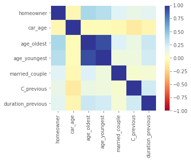

```python
# the same information displayed visually
plt.imshow(
    df[predictors].corr(), # the correlation matrix
    vmin=-1,       # minimum value for the colorbar
    vmax=1,        # maximum value for the colorbar
    cmap='RdYlBu', # color scheme
)
plt.grid(False)

# label the axes:
plt.xticks(range(len(predictors)), labels=predictors, rotation=90)
plt.yticks(range(len(predictors)), labels=predictors)
plt.colorbar()
```

The correlation between `age_youngest` and `age_oldest` is 0.917221, and due to this, we remove `age_oldest` - the two predictors are redundant and carry almost the same information.

#### 8.3:

Refit `model_region` after dropping these redundant predictor(s); call this `model_region_no_oldest`.

**Answer.** One possible solution is given below:

```python
df_drop_oldest = df_region.drop(columns=['age_oldest'])
train_drop_oldest = df_drop_oldest.loc[idx_train]
test_drop_oldest = df_drop_oldest.loc[idx_test]
model_region_no_oldest = smf.ols(formula = 'cost ~ region + car_value + A + E + F + G + homeowner + car_age + age_youngest + married_couple + C_previous + duration_previous + I(age_youngest**2) + I(car_age**2) + car_value*age_youngest', data = train_drop_oldest).fit()
print(model_region_no_oldest.summary())
```

```
                            OLS Regression Results
==============================================================================
Dep. Variable:                   cost   R-squared:                       0.373
Model:                            OLS   Adj. R-squared:                  0.371
Method:                 Least Squares   F-statistic:                     203.5
Date:                Mon, 16 Mar 2020   Prob (F-statistic):               0.00
Time:                        14:18:26   Log-Likelihood:                -62223.
No. Observations:               12344   AIC:                         1.245e+05
Df Residuals:                   12307   BIC:                         1.248e+05
Df Model:                          36
Covariance Type:            nonrobust
===============================================================================================
                                  coef    std err          t      P>|t|      [0.025      0.975]
-----------------------------------------------------------------------------------------------
Intercept                     707.6063     23.499     30.113      0.000     661.545     753.667
region[T.Northeast]            32.7322      1.233     26.547      0.000      30.315      35.149
region[T.South]                23.8143      1.019     23.380      0.000      21.818      25.811
region[T.West]                 13.7000      1.198     11.440      0.000      11.353      16.047
car_value[T.b]                -84.2031     29.136     -2.890      0.004    -141.314     -27.092
car_value[T.c]                -37.1793     23.660     -1.571      0.116     -83.557       9.198
car_value[T.d]                -47.4008     23.508     -2.016      0.044     -93.480      -1.322
car_value[T.e]                -39.6390     23.465     -1.689      0.091     -85.634       6.356
car_value[T.f]                -38.1166     23.488     -1.623      0.105     -84.156       7.923
car_value[T.g]                -30.2810     23.583     -1.284      0.199     -76.508      15.946
car_value[T.h]                -13.0424     24.048     -0.542      0.588     -60.181      34.096
car_value[T.i]                 31.9904     29.064      1.101      0.271     -24.980      88.961
A[T.1]                         40.2951      1.383     29.138      0.000      37.584      43.006
A[T.2]                         45.0018      1.739     25.874      0.000      41.593      48.411
E[T.1]                         12.1260      0.795     15.259      0.000      10.568      13.684
F[T.1]                         -4.1958      1.320     -3.180      0.001      -6.783      -1.609
F[T.2]                         -3.5549      1.285     -2.767      0.006      -6.073      -1.036
F[T.3]                         -7.4113      2.205     -3.362      0.001     -11.733      -3.090
G[T.2]                         11.2725      0.935     12.061      0.000       9.441      13.104
G[T.3]                          7.4586      1.058      7.052      0.000       5.385       9.532
G[T.4]                          8.1863      1.261      6.492      0.000       5.714      10.658
homeowner                     -13.1223      0.748    -17.540      0.000     -14.589     -11.656
car_age                        -1.4034      0.165     -8.502      0.000      -1.727      -1.080
age_youngest                   -2.7194      0.418     -6.499      0.000      -3.540      -1.899
car_value[T.b]:age_youngest     0.6811      0.560      1.216      0.224      -0.417       1.779
car_value[T.c]:age_youngest     0.1619      0.415      0.391      0.696      -0.651       0.974
car_value[T.d]:age_youngest     0.5024      0.403      1.247      0.213      -0.288       1.292
car_value[T.e]:age_youngest     0.3477      0.401      0.866      0.386      -0.439       1.135
car_value[T.f]:age_youngest     0.3144      0.402      0.782      0.434      -0.474       1.102
car_value[T.g]:age_youngest     0.2368      0.404      0.586      0.558      -0.555       1.029
car_value[T.h]:age_youngest     0.0254      0.414      0.061      0.951      -0.786       0.836
car_value[T.i]:age_youngest    -0.3286      0.519     -0.633      0.527      -1.346       0.689
married_couple                 -4.6107      0.856     -5.385      0.000      -6.289      -2.932
C_previous                     -6.8000      0.321    -21.178      0.000      -7.429      -6.171
duration_previous              -1.4024      0.076    -18.493      0.000      -1.551      -1.254
I(age_youngest ** 2)            0.0209      0.001     15.886      0.000       0.018       0.023
I(car_age ** 2)                 0.0363      0.007      4.862      0.000       0.022       0.051
==============================================================================
Omnibus:                      442.604   Durbin-Watson:                   1.981
Prob(Omnibus):                  0.000   Jarque-Bera (JB):              819.639
Skew:                           0.284   Prob(JB):                    1.04e-178
Kurtosis:                       4.127   Cond. No.                     5.72e+05
==============================================================================

Warnings:
[1] Standard Errors assume that the covariance matrix of the errors is correctly specified.
[2] The condition number is large, 5.72e+05. This might indicate that there are
strong multicollinearity or other numerical problems.
```

We notice that the coefficient for `age_youngest` has changed: it has gone from `-3.0910` in the previous model to `-2.7194`. In extreme cases, the sign of the coefficient can even flip. This illustrates how much multicollinearity can destabilize a model.

#### 8.4

What would you do to diagnose the `model_region_no_oldest` fit? What does this diagnosis suggest to you? (Hint: try plotting the residuals in various ways.)

**Answer.** A natural step is to visualize the residuals, via plots like histograms and the QQ plot. Let's start with the histogram:

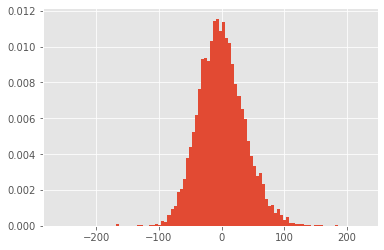

```python
plt.hist(model_region_no_oldest.resid,
    density=True,     # the histogram integrates to 1
                      # (so it can be compared to the normal distribution)
    bins=100,         #  draw a histogram with 100 bins of equal width
    label='residuals' # label for legend
);
```

This seems ok. Let's look at the QQ plot now:

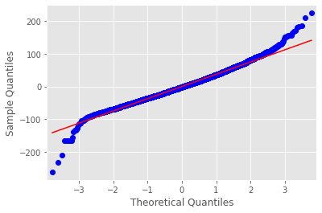

```python
sm.qqplot(model_region_no_oldest.resid, line='s');
```

Now we begin to see some issues. We notice that the far away quantiles do not conform to the line – this means that the tails are fatter than were apparent at first from the histogram. This means that we should consider some variable transformations to get this back in line.

### Exercise 9 (25 min):

#### 9.1

Find the best Box-Cox transformation of `cost` used to fit `model_region_no_oldest`. What value do you get?

**Answer.** Shown below:

```python
from scipy import stats

price, fitted_lambda = stats.boxcox(df_drop_oldest['cost'])
round(fitted_lambda, 2)
```

```
0.53
```

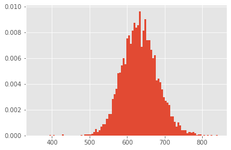

```python
plt.hist(df_drop_oldest['cost'], density=True, bins = 100);
```

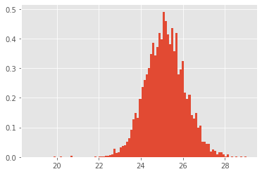

```python
plt.hist(np.sqrt(df_drop_oldest['cost']), density=True, bins = 100);
```

They both look okay, though the square root transformation looks slightly better visually.

#### 9.2

Refit `model_region_no_oldest`, but now with the transformation as suggested by the Box-Cox. Call it `model_region_no_oldest_box_cox`.

**Answer.** One possible solution is shown below:

```python
df_drop_oldest['cost_sqrt'] = np.sqrt(df_drop_oldest['cost'])
train_drop_oldest = df_drop_oldest.loc[idx_train]
test_drop_oldest = df_drop_oldest.loc[idx_test]
model_region_no_oldest_box_cox = smf.ols(formula = 'cost_sqrt ~ group_size + homeowner + car_age + car_value + risk_factor + age_youngest + married_couple + C_previous + duration_previous + A + B + C + D + E + F + G + region', data = train_drop_oldest).fit()
print(model_region_no_oldest_box_cox.summary())
```

```
                            OLS Regression Results
==============================================================================
Dep. Variable:              cost_sqrt   R-squared:                       0.365
Model:                            OLS   Adj. R-squared:                  0.363
Method:                 Least Squares   F-statistic:                     207.7
Date:                Mon, 16 Mar 2020   Prob (F-statistic):               0.00
Time:                        14:18:44   Log-Likelihood:                -13929.
No. Observations:               12344   AIC:                         2.793e+04
Df Residuals:                   12309   BIC:                         2.819e+04
Df Model:                          34
Covariance Type:            nonrobust
=======================================================================================
                          coef    std err          t      P>|t|      [0.025      0.975]
---------------------------------------------------------------------------------------
Intercept              25.8739      0.178    145.286      0.000      25.525      26.223
car_value[T.b]         -1.5106      0.209     -7.240      0.000      -1.920      -1.102
car_value[T.c]         -1.1799      0.171     -6.916      0.000      -1.514      -0.845
car_value[T.d]         -1.1327      0.169     -6.717      0.000      -1.463      -0.802
car_value[T.e]         -1.1196      0.168     -6.652      0.000      -1.450      -0.790
car_value[T.f]         -1.1300      0.169     -6.703      0.000      -1.460      -0.800
car_value[T.g]         -1.0503      0.169     -6.212      0.000      -1.382      -0.719
car_value[T.h]         -0.9189      0.171     -5.358      0.000      -1.255      -0.583
car_value[T.i]         -0.4273      0.189     -2.262      0.024      -0.798      -0.057
A[T.1]                  0.7897      0.028     28.135      0.000       0.735       0.845
A[T.2]                  0.8881      0.035     25.371      0.000       0.820       0.957
B[T.1]                  0.0327      0.016      2.012      0.044       0.001       0.065
C[T.2]                  0.0062      0.023      0.275      0.783      -0.038       0.051
C[T.3]                  0.0152      0.024      0.646      0.518      -0.031       0.061
C[T.4]                  0.0557      0.036      1.564      0.118      -0.014       0.126
D[T.2]                  0.0192      0.025      0.773      0.439      -0.030       0.068
D[T.3]                  0.0272      0.026      1.062      0.288      -0.023       0.077
E[T.1]                  0.2075      0.018     11.529      0.000       0.172       0.243
F[T.1]                 -0.0693      0.026     -2.621      0.009      -0.121      -0.017
F[T.2]                 -0.0611      0.026     -2.369      0.018      -0.112      -0.011
F[T.3]                 -0.1466      0.044     -3.313      0.001      -0.233      -0.060
G[T.2]                  0.2262      0.019     12.106      0.000       0.190       0.263
G[T.3]                  0.1502      0.021      7.064      0.000       0.108       0.192
G[T.4]                  0.1602      0.025      6.342      0.000       0.111       0.210
region[T.Northeast]     0.6510      0.025     26.327      0.000       0.603       0.699
region[T.South]         0.4825      0.021     23.141      0.000       0.442       0.523
region[T.West]          0.2762      0.024     11.436      0.000       0.229       0.324
group_size              0.2141      0.024      8.800      0.000       0.166       0.262
homeowner              -0.2875      0.015    -19.046      0.000      -0.317      -0.258
car_age                -0.0140      0.001     -9.829      0.000      -0.017      -0.011
risk_factor             0.0127      0.005      2.814      0.005       0.004       0.022
age_youngest           -0.0083      0.000    -18.919      0.000      -0.009      -0.007
married_couple         -0.2790      0.027    -10.284      0.000      -0.332      -0.226
C_previous             -0.1356      0.007    -18.122      0.000      -0.150      -0.121
duration_previous      -0.0280      0.002    -18.393      0.000      -0.031      -0.025
==============================================================================
Omnibus:                      329.734   Durbin-Watson:                   1.985
Prob(Omnibus):                  0.000   Jarque-Bera (JB):              696.051
Skew:                           0.155   Prob(JB):                    7.15e-152
Kurtosis:                       4.121   Cond. No.                     3.60e+03
==============================================================================

Warnings:
[1] Standard Errors assume that the covariance matrix of the errors is correctly specified.
[2] The condition number is large, 3.6e+03. This might indicate that there are
strong multicollinearity or other numerical problems.
```

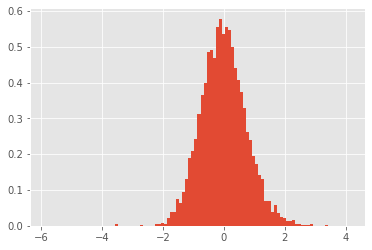

```python
plt.hist(model_region_no_oldest_box_cox.resid,
    density=True,     # the histogram integrates to 1
                      # (so it can be compared to the normal distribution)
    bins=100,         #  draw a histogram with 100 bins of equal width
    label='residuals' # label for legend
);
```

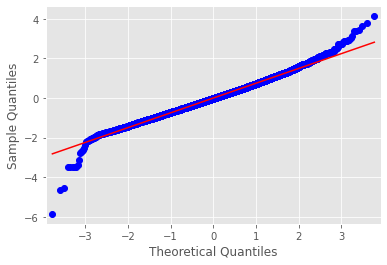

```python
sm.qqplot(model_region_no_oldest_box_cox.resid, line='s');
```

We see that the AIC of `model_region_no_oldest_box_cox` is much better than that of `model_region_no_oldest`. However, the QQ plot is still exhibiting strange tail behavior.

## Conclusion

In this, you practiced creating linear models using `statsmodels` and iteratively trimming the input variables to go from including all the variables in the dataset to using only the most relevant variables. You excluded those variables that were statistically insignificant and removed those that had high correlation. Finally, we performed some feature engineering in an attempt to remove some tail behavior that deviates from the normal distribution to better fit our linear model. In the end, we had a very minimal model that contained variables that other insurance companies use to charge premiums that gave us insight on how we can better serve a niche population.